# Final Project - Milk Quality

#### Correlation Plot

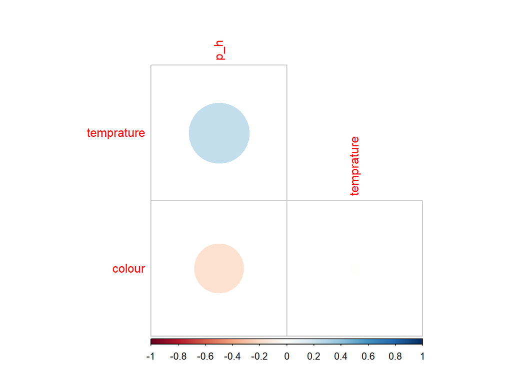

```r
milk %>%
  select(where(is.numeric)) %>%
  cor(use = 'complete.obs') %>%
  corrplot(type = 'lower', diag = FALSE)
```

From the plot we can see that in general, temperature and pH is positively related so in general if we want higher pH milk we can heat up the milk. It is interesting that pH and color is negatively related(higher pH milk has more dim color) but the temperature does not affect much on color.

## Model Setting Up

### Splitting Data

```r
milk_split<-initial_split(milk, prop=0.8, strata = 'grade')
milk_train<-training(milk_split)    # training data
milk_test<-testing(milk_split)    # testing data

dim(milk_train)
```

```
## [1] 846   8
```

```r
dim(milk_test)
```

```
## [1] 213   8
```

### K-Fold Cross Validation for resampling

```r
milk_folds<-vfold_cv(milk_train,v=5,strata = 'grade')
```

### Building Recipe

```r
milk_recipe<-
  recipe(grade~.,data = milk_train) %>%
  step_dummy(all_nominal_predictors()) %>%
  step_center(all_predictors()) %>%
  step_scale(all_predictors()) %>%
  step_normalize()
```

## Model Building

### Logistic Regression

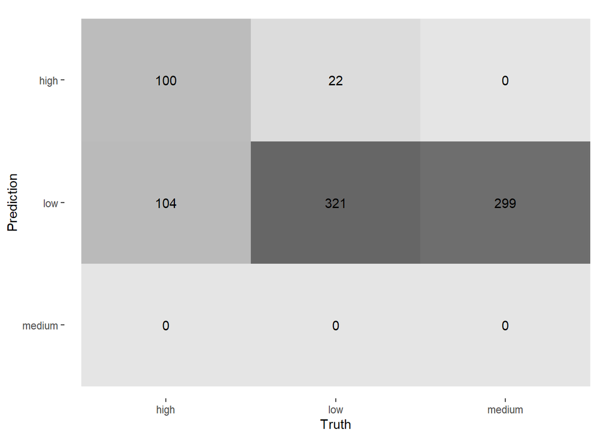

```r
log_reg <- logistic_reg() %>%
  set_engine("glm") %>%
  set_mode("classification")

log_wkflow <- workflow() %>%
  add_model(log_reg) %>%
  add_recipe(milk_recipe)

log_fit<-fit(log_wkflow,milk_train)

augment(log_fit, new_data = milk_train) %>%
  conf_mat(truth = grade, estimate = .pred_class) %>%
  autoplot(type = "heatmap")
```

The accuracy is 0.498. Not performing very well. From the heat map we can tell it gives the best prediction of low grade milk.

### Classification Tree

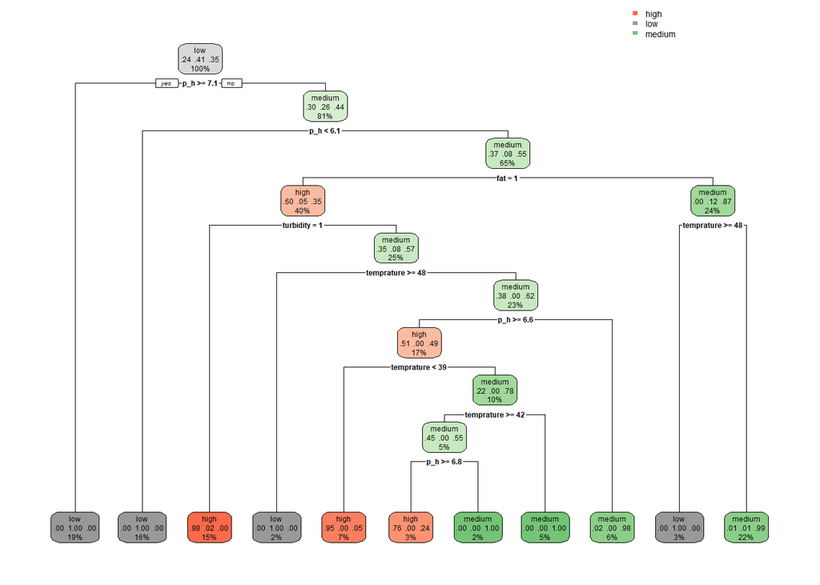

```r
library(rpart.plot)
ct_model <- decision_tree() %>%
  set_engine("rpart") %>%
  set_mode("classification")

ct_fit <- ct_model %>%
  fit(grade ~ ., data = milk_train)

ct_fit %>%
  extract_fit_engine() %>%
  rpart.plot(roundint=FALSE)
```

```r
augment(ct_fit, new_data = milk_train) %>%
  accuracy(truth = grade, estimate = .pred_class)
```

```
## # A tibble: 1 × 3
##   .metric  .estimator .estimate
##   <chr>    <chr>          <dbl>
## 1 accuracy multiclass     0.983
```

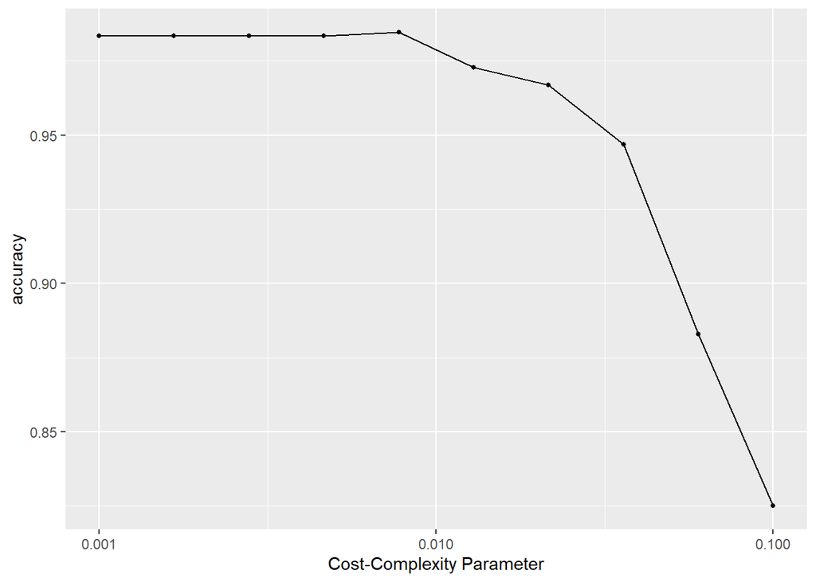

```r
ct_wkflow <- workflow() %>%
  add_model(ct_model %>% set_args(cost_complexity = tune())) %>%
  add_formula(grade ~ .)

param_grid <- grid_regular(cost_complexity(range = c(-3, -1)), levels = 10)

ct_tune <- tune_grid(
  ct_wkflow,
  resamples = milk_folds,
  grid = param_grid,
  metrics = metric_set(accuracy))

autoplot(ct_tune)
```

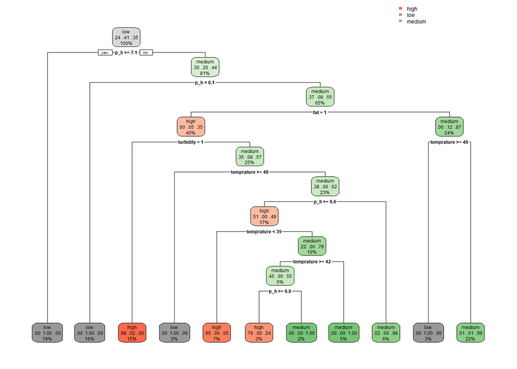

```r
# Best Classification Tree

best_complexity <- select_best(ct_tune)

class_tree_final <- finalize_workflow(ct_wkflow, best_complexity)

class_tree_final_fit <- fit(class_tree_final, data = milk_train)

class_tree_final_fit %>%
  extract_fit_engine() %>%
  rpart.plot(roundint=FALSE)
```

From the cost complexity parameter estimate the accuracy is approximately 0.98, which is very good result.